# Chapter 11: Capital Budgeting

FINA 3000 · Business Finance I · Class 21

Dr. Justin Mohr

November 3, 2026

## Net Present Value

- Net Present Value measures the increase/decrease in shareholder wealth due to a company undertaking a capital project
- Typically, CF0 is an immediate cash outflow and the remaining cash flows are cash inflows

$$NPV = CF_0 + \frac{CF_1}{\left( 1 + WACC \right)^1} + \frac{CF_2}{\left( 1 + WACC \right)^2} ................................................$$

- WACC=discount rate=cost of capital
- CFt=Cash Flow in Year t
- t=year

## IRR

- This is the rate at which the NPV will be zero.
- If IRR>WACC we accept the project
- If IRR<WACC we reject the project

## Project types

Independent projects: If the cash flows of one are unaffected by the acceptance of the other.

Mutually exclusive projects: If the cash flows of one can be adversely impacted by the acceptance of the other.

- NPV=PV of inflows - PV of outflows=Net gain in wealth
  - If projects are independent, accept if the project NPV > 0.
  - If projects are mutually exclusive, accept project with the highest positive NPV, one that adds the most shareholder value.
- IRR
  - If projects are independent, accept all projects if IRR > WACC
  - If projects are mutually exclusive, accept project with higher IRR

## Normal vs Nonnormal CF

Normal cash flows: Cost (negative CF) followed by a series of positive cash inflows. One change of signs.

Non-normal cash flows: Two or more changes of signs.

Most common non-normal: Cost (negative CF), then string of positive CFs, then cost to close project. Examples include nuclear power plant, strip mine, etc.

## An Extreme Example

- Sivovist Mining is considering a small strip mining operation. It will cost -1.6M in the first year. Then there will be revenue of 10M in the second year, and then then a clean up cost of 10M.
- Find the NPV at 0%, 10%, 100%, 500%. Make a plot.
- Why are these values so strange?

## Extreme Example (NPV Profile)

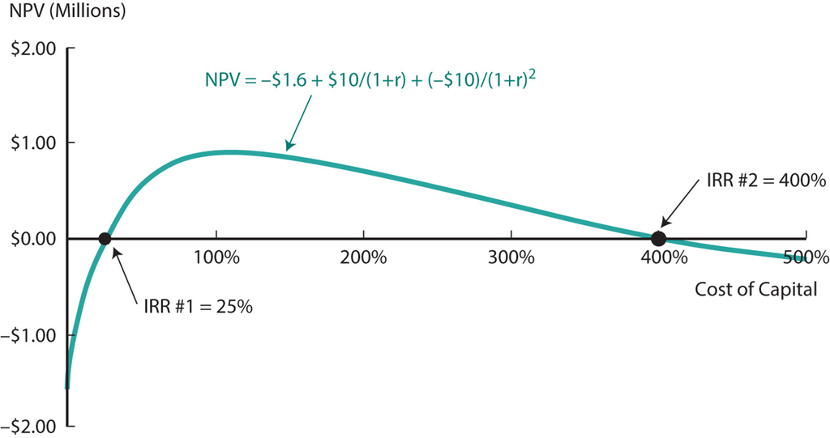

## Reason for multiple IRR

At very low discount rates, the PV of CF2 is large and negative, so NPV < 0.

At very high discount rates, the PV of both CF1 and CF2 are low, so CF0 dominates and again NPV < 0.

In between, the discount rate hits CF2 harder than CF1, so NPV > 0.

Result: 2 IRRs.

Conclusion: Use alternatives when IRR is very high and/or project has non-normal cash flows

## Nonnormal cash flows

- This specific case
  - With a large enough discount rate, then the future cost is depressed enough down
  - Sanity check: Would we do it if money was free?
- In general: IRR is nice, it can tell me when the NPV will be zero
  - It has issues, multiple solutions is one
  - Also there is a reinvestment rate assumption

## Reinvestment assumption

When we discount we assume that the CF can be reinvested at the discount rate

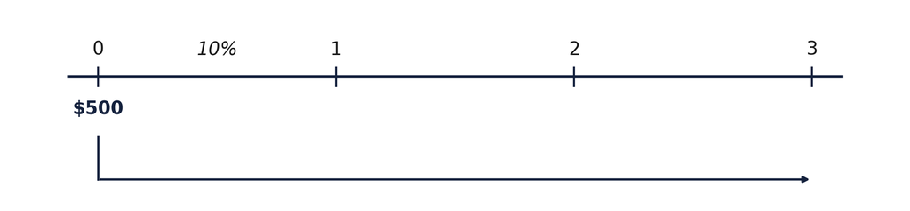

$$\$500 \left( 1 + 10\% \right)^3 = 665.50$$

## Reinvestment assumption

When we discount we assume that the CF can be reinvested at the discount rate

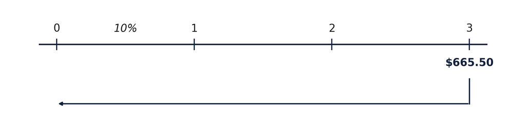

$$\$500 = \frac{665.50}{1.1^3}$$

## Is this reasonable?

- IRR assumes that funds are being reinvested at the IRR
- NPV assumes that funds are reinvested at the WACC
- Which is more reasonable?
- Assume that Justin’s Cupcakes has a WACC of 10% and the project has an IRR of 50%
- If the firm invests the CFs of the project into other projects, which rate is more reasonable?

## Aside: PE/VC and IRR

- The main use of IRR outside of capital budgeting in in PE/VC
- I am going to summarize a 3 part series on the CFA institute by Dr. Phalippou
- https://blogs.cfainstitute.org/investor/author/ludovicphalippou/
- Strongly encourage you to give it a read

## Your inoculation against misstated IRR

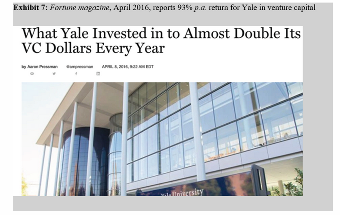

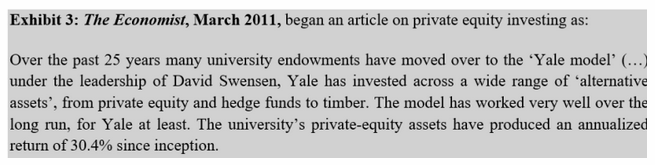

## PE allocations have grown globally

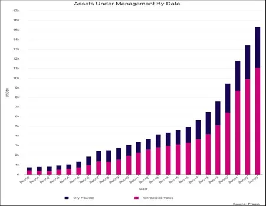

Dr. Phalippou “believe(s) that a root cause for this belief is the generalized use of IRR to infer rates of return, which is problematic.”

## The smell test

- “The issue with IRR is the unrealistic implicit assumption it makes about financing costs and reinvestment costs. When IRR is high, this assumption is unrealistic by definition. ”
- “A simple way to see that IRR is unlikely to be a rate of return is to compute how much money investors would be sitting on if they had obtained a rate of return equal to the IRR.”

## Private equity for ordinary investors?

> Expanding the pool of potential investors is a priority of the private-equity industry at a time when many institutions such as pension funds and endowments are pulling back from the asset class. The industry’s main problem has been its inability to unload companies at attractive prices, leaving a huge backlog of unsold assets.

> Private-equity fundraising has declined every year since 2023, a trend “driven by underwhelming returns” in the period since the frothy postpandemic years, according to data-tracking firm PitchBook. U.S. private-equity managers raised about $160 billion this year through June 30, roughly in line with 2025’s muted total, PitchBook said.

> The SEC’s actions could help relieve the industry’s challenges. “We appreciate the SEC’s recognition of the longstanding role private markets have played in securing America’s public pensions—providing strong, stable returns and vital diversification for decades,” said Will Dunham, president and chief executive of the American Investment Council, private equity’s largest trade group.

Institutions are pulling back and returns have underwhelmed. Why does the industry want ordinary investors now?

[The Wall Street Journal, “SEC Moves to Give Ordinary Investors More Access to Private Equity”](https://www.wsj.com/pro/private-equity/sec-moves-to-give-ordinary-investors-more-access-to-private-equity-d4108681?mod=itp_wsj)

## Can we save IRR

- One of the issues is that we assume that CFs will earn the IRR!
- We can change that!
- We will modify it to be MIRR

## MIRR

- Assume that cash-flows can earn some rate, WACC.
- Then what is the discount rate that your CF0 would have to earn to get that FV

$$PV\ Costs = \frac{TV}{\left( 1 + MIRR \right)^N}$$

$$\sum \frac{COF_t}{\left( 1 + r \right)^t} = \frac{\sum CIF_t \left( 1 + r \right)^{N-t}}{\left( 1 + MIRR \right)^N}$$

- Get the PV of the outflows and the FV of the inflows. The rate that sets them equal is the MIRR

## First Simple Example

- Assume CFs are as follows: CF0: -100, CF1: 100, CF2: 100 and the WACC is 10% find the MIRR.

$$\sum \frac{COF_t}{\left( 1 + r \right)^t} = \frac{\sum CIF_t \left( 1 + r \right)^{N-t}}{\left( 1 + MIRR \right)^N}$$

- First, we need the PV of our costs
- All negative signs, -100
- That is PV of our costs
- Now FV of each of our positive Numbers
- FV(CF2) is 100
- FV(CF1) is 100(1+10%)=110
- 210

## First Simple Example Cont.

- Assume CFs are as follows: CF0: -100, CF1: 100, CF2: 100 and the WACC is 10% find the MIRR.

$$100 = \frac{210}{\left( 1 + MIRR \right)^2}$$

- Solve for rate with PV of -100, FV of 210 and 2 time periods

N2I/Y?PV-100PMT0FV210

CPT I/Y44.91%

## Second Simple Example

- Assume CFs are as follows: CF0: -100, CF1: -110, CF2: 250 and the WACC is 10% find the MIRR.

$$\sum \frac{COF_t}{\left( 1 + r \right)^t} = \frac{\sum CIF_t \left( 1 + r \right)^{N-t}}{\left( 1 + MIRR \right)^N}$$

- First, we need the PV of our costs
- All negative signs, CF0 and PV(CF1)

$$-100 + \frac{-110}{1 + 10\%} = 200$$

- Now FV of each of our positive Numbers
- FV(CF2) is 250

## Second Simple Example Cont.

$$200 = \frac{250}{\left( 1 + MIRR \right)^2}$$

- Solve for rate with PV of -200, FV of 250 and 2 time periods

N2I/Y?PV-200PMT0FV250

CPT I/Y11.80%

## Cupcake Wars

- In their continuing war to be the top cupcake producer in Northern Mississippi, Taylor’s Cupcakes is planning their largest expansion yet to Olive Branch. It will cost 275K intially. The CF for the following 5 years are 87,000, 99,000, 69,000, 61,000, and 92,800. The WACC is 10%
- Step 1: Find the PV of all the inflows (positive numbers)
  - Enter all CF to the register except Cfo. Find NPV

$312,035.13

- Now get FV of that $312K
  - -312035.13 into [PV], 5 into [N], and 10 into [I/YR]

N5I/Y10PV-312,035.13PMT0FV?

CPT FV$502,535.70

- Now we need the rate that sets 275K initial investment equal to 502K
  - -275,000 into [PV] and then [CPT] [I/YR]

N5I/Y?PV-275,000PMT0FV502,535.70

CPT I/Y$12.81%

## Cupcake Wars: MIRR

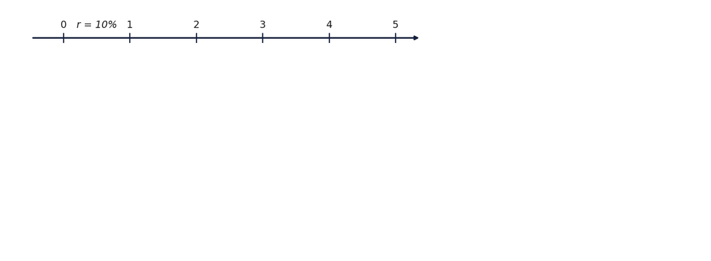

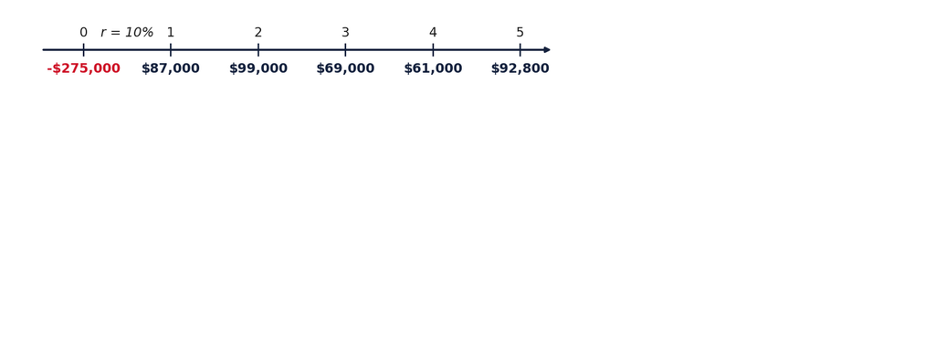

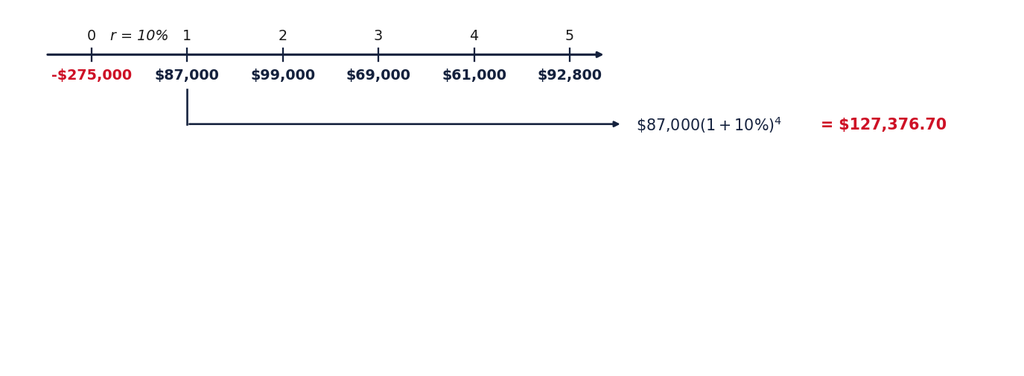

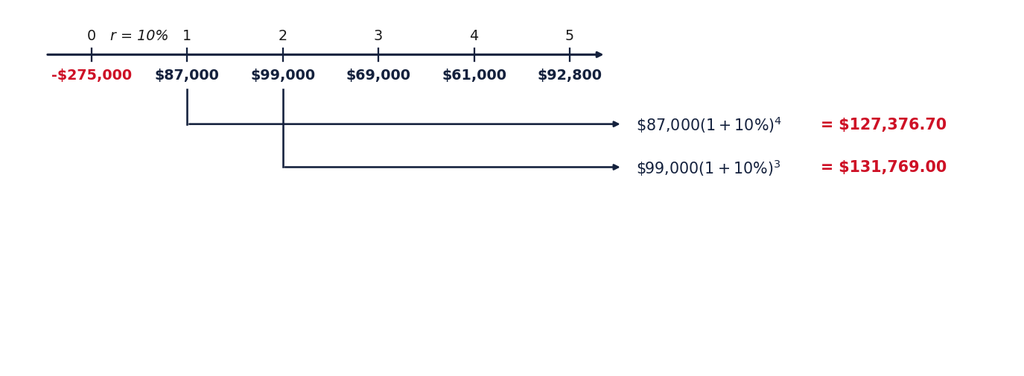

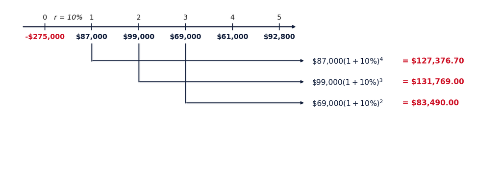

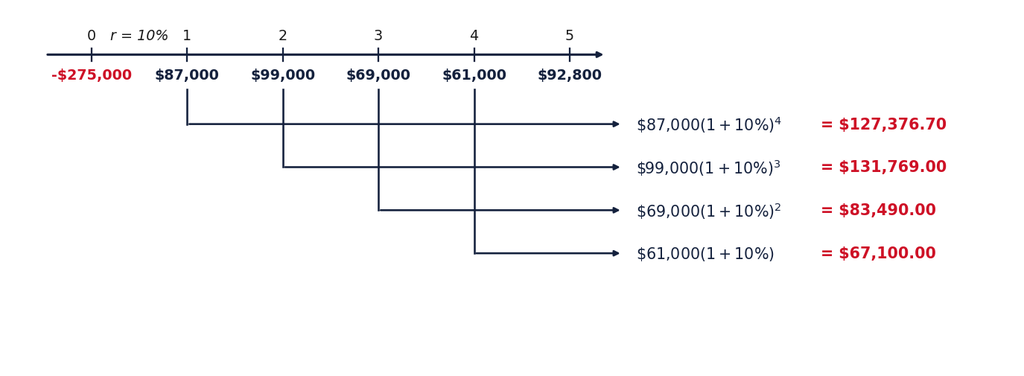

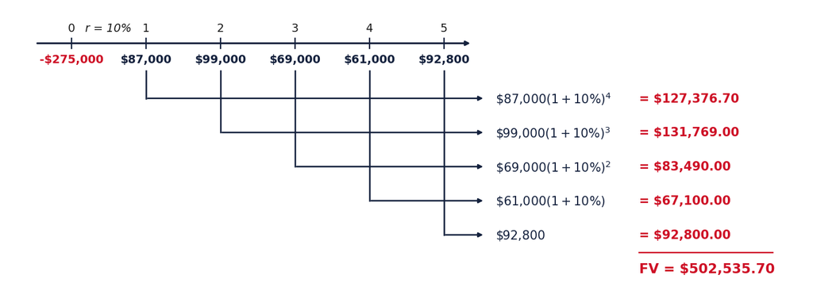

$$275{,}000 = \frac{502{,}535.70}{\left( 1 + MIRR \right)^5} \qquad MIRR = 12.81\%$$

## Crossover Rate

- The crossover rate is the WACC (discount rate or rate of return) that equates the net present value of two mutually exclusive capital projects
- It is the rate at which one mutually exclusive project becomes more attractive than the other as measured by NPV
- Different decisions are made about which mutually exclusive project to accept at discount rates (or Weighted Average Costs of Capital) that are above or below the crossover rate

## Crossover Rate

- Find the NPV of A and B at 0% and at 10%
- Which project do you prefer at 0%? At 10%?

Two mutually exclusive projects, NPVs worked

| YEAR | A | B |
| --- | --- | --- |
| 0 | -100 | -100 |
| 1 | 10 | 70 |
| 2 | 60 | 50 |
| 3 | 80 | 20 |
| NPV at 0% WACC | $50 | $40 |
| NPV at 10% WACC | $18.78 | $19.98 |
| IRR | 18.13% | 23.56% |

- A is more attractive at a WACC of 0%
- B is more attractive at a WACC of 10%

What is the rate at which our answer changes?

## Crossover Rate

The IRR of the difference IS the crossover rate

| YEAR | A | B | ΔCF |
| --- | --- | --- | --- |
| 0 | -100 | -100 | 0 |
| 1 | 10 | 70 | -60 |
| 2 | 60 | 50 | 10 |
| 3 | 80 | 20 | 60 |

8.68%

- ΔCF is the differences between the projects’ cash flows.
- Use IRR function to calculate IRR of ΔCF cash flows.
- The IRR of ΔCF is the crossover rate.
- IRR of ΔCF cash flows=Crossover rate=8.68%.
- Project B’s Net Present Value is higher than A’s if the WACC > 8.68%
- Project A’s Net Present Value is higher than B’s if the WACC<8.68%
- If a crossover rate does not exist, one project has a higher NPV than the other at all costs of capital

## Plotting the NPV Profiles

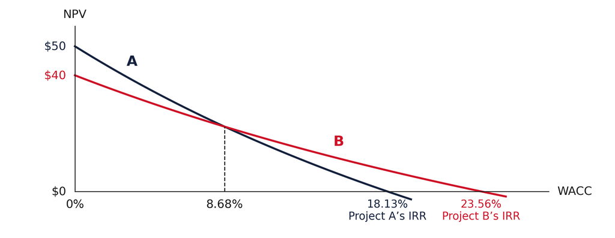

- The Y intercept is net present value of each project at a zero discount rate (or WACC)
- The X intercept is the rate of return that results in a zero NPV, also known as the internal rate of return (IRR)

## IRR and NPV Conflicts

NPV is a better measure of shareholder wealth creation, but IRR is easier to understand

With mutually exclusive projects, accept one with higher NPV vs with one with higher IRR

If projects are independent, accept all where IRR>WACC

## Payback period

- The number of years required to recover a project’s cost
- Calculated by adding a project’s cash inflows to its cost until the cumulative cash flow for the project turns positive.
- Strengths
  - Provides an indication of a project’s risk and liquidity.
  - Easy to calculate and understand.
- Weaknesses
  - Ignores the time value of money (TVM).
  - Ignores CFs occurring after the payback period.
  - No relationship between a given payback and shareholder wealth maximization.

## Payback and Discounted Payback

$$\begin{aligned} Payback = {} & \text{Number of years prior to full recovery} \ & + \frac{\text{Unrecovered cost at start of year}}{\text{Cash flow during full recovery year}} \end{aligned}$$

- Project Payback Calculation

Project L’s cash flows

|  | 0 | 1 | 2 | 3 |
| --- | --- | --- | --- | --- |
| CF<sub>t</sub> | -100 | 10 | 60 | 80 |

Project L’s cumulative cash flow

|  | 0 | 1 | 2 | 3 |
| --- | --- | --- | --- | --- |
| Cumulative | -100 | -90 | -30 | 50 |

$$Payback_L = 2 + \frac{30}{80} = 2.375 \text{ years}$$

$$Payback_S = 1.600 \text{ years}$$

- Discounted Payback: Uses discounted cash flows rather than nominal CFs.

Project L’s cash flows at 10%

| 10% | 0 | 1 | 2 | 3 |
| --- | --- | --- | --- | --- |
| CF<sub>t</sub> | -100 | 10 | 60 | 80 |

Project L’s discounted cumulative cash flow

|  | 0 | 1 | 2 | 3 |
| --- | --- | --- | --- | --- |
| PV of CF<sub>t</sub> | -100 | 9.09 | 49.59 | 60.11 |
| Cumulative | -100 | -90.91 | -41.32 | 18.79 |

$$Disc\ Payback_L = 2 + \frac{41.32}{60.11} = 2.7 \text{ years}$$

## Capital Budgeting

Two projects and the difference between them

| Time | Project A | Project B | Diff(A-B) |
| --- | --- | --- | --- |
| 0 | -300 | -405 | 105 |
| 1 | -387 | 134 | -521 |
| 2 | -193 | 134 | -327 |
| 3 | -100 | 134 | -234 |
| 4 | 600 | 134 | 466 |
| 5 | 600 | 134 | 466 |
| 6 | 850 | 134 | 716 |
| 7 | -180 | 0 | -180 |

- WACC is 11%
- Find the NPV and IRR of these projects
- Find the MIRR for B
- What is the crossover rate? (Where the NPVs equal)

## Capital Budgeting

Two projects and the difference between them

| Time | Project A | Project B | Diff(A-B) |
| --- | --- | --- | --- |
| 0 | -300 | -405 | 105 |
| 1 | -387 | 134 | -521 |
| 2 | -193 | 134 | -327 |
| 3 | -100 | 134 | -234 |
| 4 | 600 | 134 | 466 |
| 5 | 600 | 134 | 466 |
| 6 | 850 | 134 | 716 |
| 7 | -180 | 0 | -180 |

- NPV
  - Use the Cash flow register
  - NPV function
  - I=WACC=11
  - Up to NPV and then CPT

Project A: $240.64

Project B: $161.86

## Capital Budgeting

Two projects and the difference between them

| Time | Project A | Project B | Diff(A-B) |
| --- | --- | --- | --- |
| 0 | -300 | -405 | 105 |
| 1 | -387 | 134 | -521 |
| 2 | -193 | 134 | -327 |
| 3 | -100 | 134 | -234 |
| 4 | 600 | 134 | 466 |
| 5 | 600 | 134 | 466 |
| 6 | 850 | 134 | 716 |
| 7 | -180 | 0 | -180 |

- IRR
  - Best to do this at the same time as NPV
  - Use the Cash flow register
  - IRR function

Project A: 18.10%

Project B: 23.97%

## Capital Budgeting

Two projects and the difference between them

| Time | Project A | Project B | Diff(A-B) |
| --- | --- | --- | --- |
| 0 | -300 | -405 | 105 |
| 1 | -387 | 134 | -521 |
| 2 | -193 | 134 | -327 |
| 3 | -100 | 134 | -234 |
| 4 | 600 | 134 | 466 |
| 5 | 600 | 134 | 466 |
| 6 | 850 | 134 | 716 |
| 7 | -180 | 0 | -180 |

- MIRR for Project B, WACC = 11%
- Step 1: PV of B’s inflows = NPV + cost

$161.86 + $405 = $566.86

- Step 2: Move it to year 7 at the WACC

N7I/Y11PV-566.86PMT0FV?

CPT FV1,176.89

## Capital Budgeting

Two projects and the difference between them

| Time | Project A | Project B | Diff(A-B) |
| --- | --- | --- | --- |
| 0 | -300 | -405 | 105 |
| 1 | -387 | 134 | -521 |
| 2 | -193 | 134 | -327 |
| 3 | -100 | 134 | -234 |
| 4 | 600 | 134 | 466 |
| 5 | 600 | 134 | 466 |
| 6 | 850 | 134 | 716 |
| 7 | -180 | 0 | -180 |

- MIRR for Project B, WACC = 11%
- Step 3: Find the rate that grows the $405 cost into $1,176.89

$$405 \left( 1 + MIRR \right)^7 = 1{,}176.89$$

- How to find Project A MIRR?

N7I/Y?PV-405PMT0FV1,176.89

CPT I/Y16.46%

## Capital Budgeting

Two projects and the difference between them

| Time | Project A | Project B | Diff(A-B) |
| --- | --- | --- | --- |
| 0 | -300 | -405 | 105 |
| 1 | -387 | 134 | -521 |
| 2 | -193 | 134 | -327 |
| 3 | -100 | 134 | -234 |
| 4 | 600 | 134 | 466 |
| 5 | 600 | 134 | 466 |
| 6 | 850 | 134 | 716 |
| 7 | -180 | 0 | -180 |

- What is the crossover rate?
  - Use the cash flow register and find the IRR of the difference in cash flows.

14.53% is the cost of capital at which you are indifferent between these projects.

## NPV Practice

- A project pays $5k per year for 10 years and then $9k per year for the following ten years. The 20 year IRR is 8.52% and the WACC is 8%. What is the NPV?
- First, what are we missing for NPV?
- How can IRR help?
- Use the cash flow register
  - 0 for CF0, 5k for 10 years, 9K for another 10 years.
  - Then use 8.52% for I and get NPV

58,824.11

- Go back and update CF register and use WACC for I.

NPV=2,698.89

## MIRR: Practice at home

X is negative

| Time | Cash Flow |
| --- | --- |
| 0 | -500 |
| 1 | 202 |
| 2 | -X |
| 3 | 196 |
| 4 | 350 |
| 5 | 451 |

- A project has the listed cash flows.
- X is negative
- The WACC is 10% and its MIRR is 14.14%

$$\sum \frac{COF_t}{\left( 1 + r \right)^t} = \frac{\sum CIF_t \left( 1 + r \right)^{N-t}}{\left( 1 + MIRR \right)^N}$$

$$500 + \frac{X}{1.1^2} = \frac{202 \left( 1.1 \right)^{5-1} + 196 \left( 1.1 \right)^{5-3} + 350 \left( 1.1 \right)^{5-4} + 451}{\left( 1 + 14.14\% \right)^5}$$

$$X = 1.1^2 \left( \frac{1368.91}{1.94} - 500 \right) = 250.01$$

## Upcoming Dates

Upcoming class dates and deadlines

| Date | Topic | Due / Notes |
| --- | --- | --- |
| Thu Nov 5 | Chapter 12: Cash Flow Estimation | - |
| Sun Nov 8 | MindTap Ch 11 | HW DUE |
| Tue Nov 10 | Chapter 12: Cash Flow Estimation | - |
| Thu Nov 12 | Review for Test 3 | Review |

**Office:** 325 Holman Hall · **Office hours:** T TH 10:50A-12:20P · jjmohr1@olemiss.edu